# Final-PUBG

Ye Yuan

12/17/2019

```r
library(tidyr)
library(ggplot2)
library(merTools)
library(pwr)
library(dplyr)
library(DT); library(broom)
library(caret)
library(visNetwork)
library(data.table)
library(dplyr)
library(ggplot2)
library(Matrix)
library(xgboost)
library(interactions)
library(effects)
```

# ● Data Chosen and Explaination

## Data Chosen

PUBG (Playerunknown’s Battlegrounds) is the most popular game in the world and also my favourite game. I am very interested in the relationship between how the player performs in the game and the final results(winPlacePerc). The goal of the analysis is to choose which feature or variable will influence the rank of the player.

```r
pubg <- read.csv("PUBG.csv")
```

```r
pubg1 <- pubg %>%
  select(Id,matchId,assists,boosts,damageDealt,headshotKills,heals,kills,matchDuration,matchType,revives,teamKills,rideDistance,swimDistance,walkDistance,weaponsAcquired,winPlacePerc)
pubg1 <- na.omit(pubg1)
```

## Variable Explaination

boosts - Number of boost items used.(Energy Drink,Painkiller,Adrenaline Syringe)

damageDealt - Total damage dealt. Note: Self inflicted damage is subtracted.

headshotKills - Number of enemy players killed with headshots.

heals - Number of healing items used.(Bandage,First Aid Kit,Med Kit)

matchType - String identifying the game mode that the data comes from. The standard modes are “solo”, “duo”, “squad”, “solo-fpp”, “duo-fpp”, and “squad-fpp”; other modes are from events or custom matches.

rideDistance - Total distance traveled in vehicles measured in meters.

swimDistance - Total distance traveled by swimming measured in meters.

walkDistance - Total distance traveled on foot measured in meters.

weaponsAcquired - Number of weapons picked up.(Guns and Bullets)

*winPlacePerc - The target of prediction. This is a percentile winning placement, where 1 corresponds to 1st place, and 0 corresponds to last place in the match. It is calculated off of maxPlace, not numGroups, so it is possible to have missing chunks in a match.

# ● Data Exploration

## Data type

```r
str(pubg1)
```

```
## 'data.frame':    4446965 obs. of  17 variables:
##  $ Id             : Factor w/ 4446966 levels "00000160737ebf",..: 2216110 4151026 532103 1216708 856522 4437931 2598153 852047 458161 3990589 ...
##  $ matchId        : Factor w/ 47965 levels "0000a43bce5eec",..: 30087 32753 3144 45262 20533 34913 31456 7685 41676 11378 ...
##  $ assists        : int  0 0 1 0 0 0 0 0 0 0 ...
##  $ boosts         : int  0 0 0 0 0 0 0 0 0 0 ...
##  $ damageDealt    : num  0 91.5 68 32.9 100 ...
##  $ headshotKills  : int  0 0 0 0 0 1 0 0 0 0 ...
##  $ heals          : int  0 0 0 0 0 0 0 0 0 0 ...
##  $ kills          : int  0 0 0 0 1 1 0 0 0 0 ...
##  $ matchDuration  : int  1306 1777 1318 1436 1424 1395 1316 1967 1375 1930 ...
##  $ matchType      : Factor w/ 16 levels "crashfpp","crashtpp",..: 16 16 3 16 14 16 16 14 15 15 ...
##  $ revives        : int  0 0 0 0 0 0 0 0 0 0 ...
##  $ teamKills      : int  0 0 0 0 0 0 0 0 0 0 ...
##  $ rideDistance   : num  0 0.0045 0 0 0 ...
##  $ swimDistance   : num  0 11 0 0 0 ...
##  $ walkDistance   : num  244.8 1434 161.8 202.7 49.8 ...
##  $ weaponsAcquired: int  1 5 2 3 2 1 1 6 4 1 ...
##  $ winPlacePerc   : num  0.444 0.64 0.775 0.167 0.188 ...
##  - attr(*, "na.action")= 'omit' Named int 2744605
##   ..- attr(*, "names")= chr "2744605"
```

## Corrplor relationship

```r
pubgcorr <-pubg %>%
  select(assists,boosts,damageDealt,headshotKills,heals,kills,matchDuration,revives,teamKills,rideDistance,swimDistance,walkDistance,weaponsAcquired,winPlacePerc)
```

```r
pubgcorr <- na.omit(pubgcorr)
```

```r
pubgcorr = cor(pubgcorr[,])
knitr::kable(round(pubgcorr, 2))
```

|  | assists | boosts | damageDealt | headshotKills | heals | kills | matchDuration | revives | teamKills | rideDistance | swimDistance | walkDistance | weaponsAcquired | winPlacePerc |
| --- | --- | --- | --- | --- | --- | --- | --- | --- | --- | --- | --- | --- | --- | --- |
| assists | 1.00 | 0.31 | 0.41 | 0.20 | 0.23 | 0.32 | -0.02 | 0.20 | 0.01 | 0.11 | 0.02 | 0.29 | 0.24 | 0.30 |
| boosts | 0.31 | 1.00 | 0.52 | 0.33 | 0.54 | 0.50 | 0.07 | 0.25 | 0.01 | 0.33 | 0.11 | 0.64 | 0.41 | 0.63 |
| damageDealt | 0.41 | 0.52 | 1.00 | 0.61 | 0.34 | 0.89 | -0.01 | 0.26 | 0.02 | 0.14 | 0.04 | 0.40 | 0.35 | 0.44 |
| headshotKills | 0.20 | 0.33 | 0.61 | 1.00 | 0.20 | 0.67 | -0.02 | 0.15 | 0.01 | 0.08 | 0.03 | 0.25 | 0.22 | 0.28 |
| heals | 0.23 | 0.54 | 0.34 | 0.20 | 1.00 | 0.31 | 0.11 | 0.24 | 0.04 | 0.30 | 0.08 | 0.43 | 0.31 | 0.43 |
| kills | 0.32 | 0.50 | 0.89 | 0.67 | 0.31 | 1.00 | -0.03 | 0.25 | 0.02 | 0.11 | 0.04 | 0.37 | 0.34 | 0.42 |
| matchDuration | -0.02 | 0.07 | -0.01 | -0.02 | 0.11 | -0.03 | 1.00 | 0.02 | 0.05 | 0.37 | 0.01 | 0.15 | 0.13 | -0.01 |
| revives | 0.20 | 0.25 | 0.26 | 0.15 | 0.24 | 0.25 | 0.02 | 1.00 | 0.03 | 0.11 | 0.02 | 0.24 | 0.17 | 0.24 |
| teamKills | 0.01 | 0.01 | 0.02 | 0.01 | 0.04 | 0.02 | 0.05 | 0.03 | 1.00 | 0.05 | 0.01 | 0.02 | 0.04 | 0.02 |
| rideDistance | 0.11 | 0.33 | 0.14 | 0.08 | 0.30 | 0.11 | 0.37 | 0.11 | 0.05 | 1.00 | 0.05 | 0.31 | 0.28 | 0.34 |
| swimDistance | 0.02 | 0.11 | 0.04 | 0.03 | 0.08 | 0.04 | 0.01 | 0.02 | 0.01 | 0.05 | 1.00 | 0.17 | 0.08 | 0.15 |
| walkDistance | 0.29 | 0.64 | 0.40 | 0.25 | 0.43 | 0.37 | 0.15 | 0.24 | 0.02 | 0.31 | 0.17 | 1.00 | 0.54 | 0.81 |
| weaponsAcquired | 0.24 | 0.41 | 0.35 | 0.22 | 0.31 | 0.34 | 0.13 | 0.17 | 0.04 | 0.28 | 0.08 | 0.54 | 1.00 | 0.58 |
| winPlacePerc | 0.30 | 0.63 | 0.44 | 0.28 | 0.43 | 0.42 | -0.01 | 0.24 | 0.02 | 0.34 | 0.15 | 0.81 | 0.58 | 1.00 |

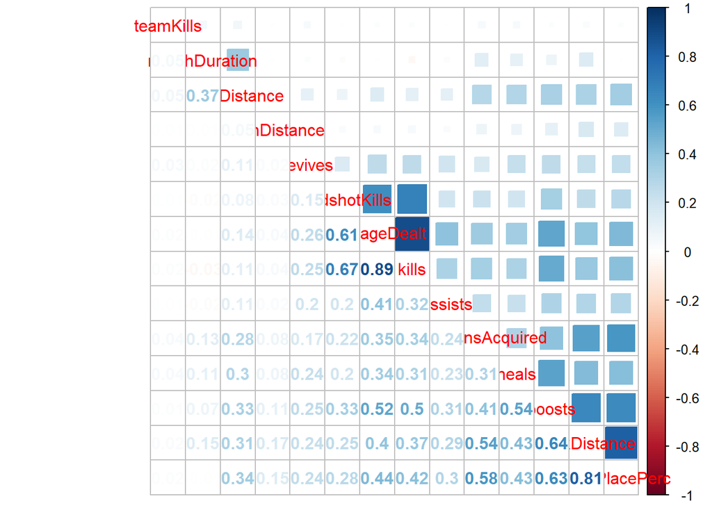

```r
corrplot::corrplot.mixed(pubgcorr, lower = "number", upper = "square", order = "hclust")
```

WalkDistance(0.81),boosts(0.63),weaponsAcquired(0.58),damageDealt(0.44),heals(0.43),kills(0.42),rideDistance(0.34) are most related to the final winPlacePrec.

We can try to group these variables:

1.Distance: walkDistance,rideDistance

2.Shooting skills: kills,damageDealt

3.Resources collection:boosts,weaponsAcquired,heals.

# ● Finding 1: Distance

Distance maters a lot,so want to see the relationship with match ranking and distance travelled.

## Analysis

First, I group the three kinds of moving methods (walk,ride,swim) and calculate their average distance. At the same time, I divide the winPlacePerc into percentage by 10% intervals.

```r
# group win placement into decile groups
dist <- pubg1 %>%
  mutate(winPlacePerc_decile = ntile(winPlacePerc, 10)) %>%
  group_by(winPlacePerc_decile) %>%
  summarise(walk = mean(walkDistance),
            ride = mean(rideDistance),
            swim = mean(swimDistance)) %>%
  ungroup() %>%
  melt(., measure.vars = c('walk', 'ride', 'swim'),
       variable.name = 'travel_mode', value.name = 'avg_distance') %>%
  as.data.table()
dist
```

```
##     winPlacePerc_decile travel_mode avg_distance
##  1:                   1        walk   58.7868745
##  2:                   2        walk  145.0416522
##  3:                   3        walk  248.6492163
##  4:                   4        walk  408.9679740
##  5:                   5        walk  653.1397844
##  6:                   6        walk 1057.6239535
##  7:                   7        walk 1560.9426158
##  8:                   8        walk 2077.5535343
##  9:                   9        walk 2509.0094969
## 10:                  10        walk 2822.4677499
## 11:                   1        ride   10.8037563
## 12:                   2        ride   29.7933105
## 13:                   3        ride   61.7465302
## 14:                   4        ride  157.4886832
```

[output cut: 17 more lines]

Then,I plot bar chart and line graph to show the relationship between travelling methods and the winplaceperc.

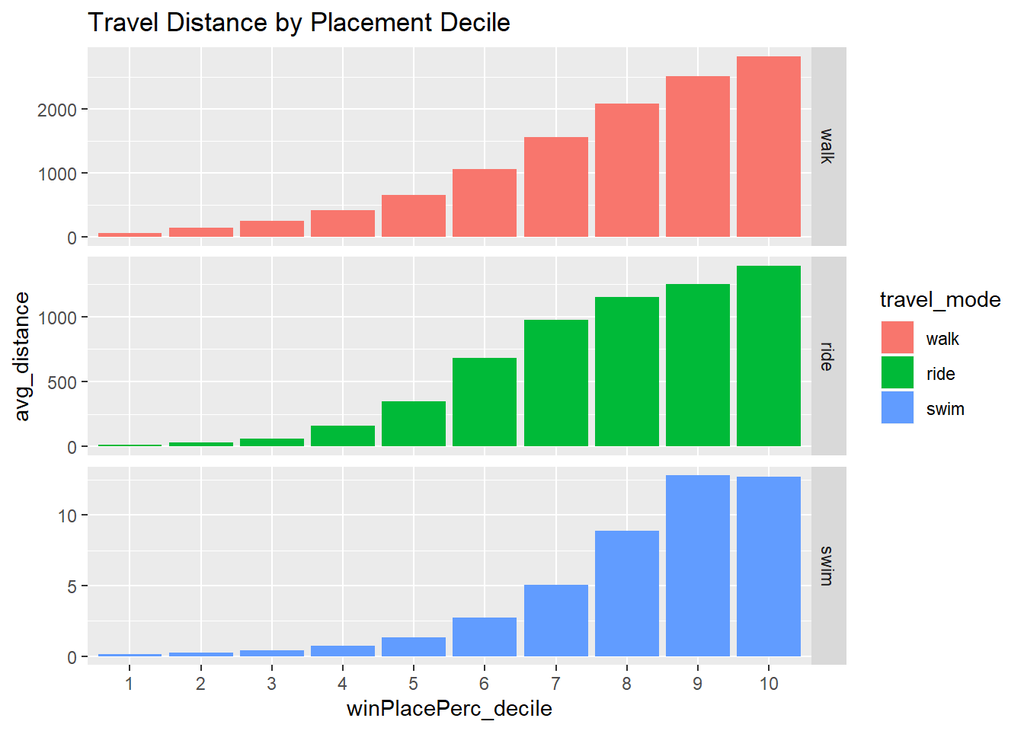

```r
# factor decile groups and plot barchart
lvls <- dist$winPlacePerc_decile %>% unique() %>% sort()
dist$winPlacePerc_decile <- factor(dist$winPlacePerc_decile, levels = lvls)
ggplot(data = dist, aes(x = winPlacePerc_decile, y = avg_distance, fill = travel_mode)) +
  geom_bar(stat = 'identity', position = 'dodge') +
  facet_grid(travel_mode ~ ., scales = 'free') +
  labs(title = 'Travel Distance by Placement Decile')
```

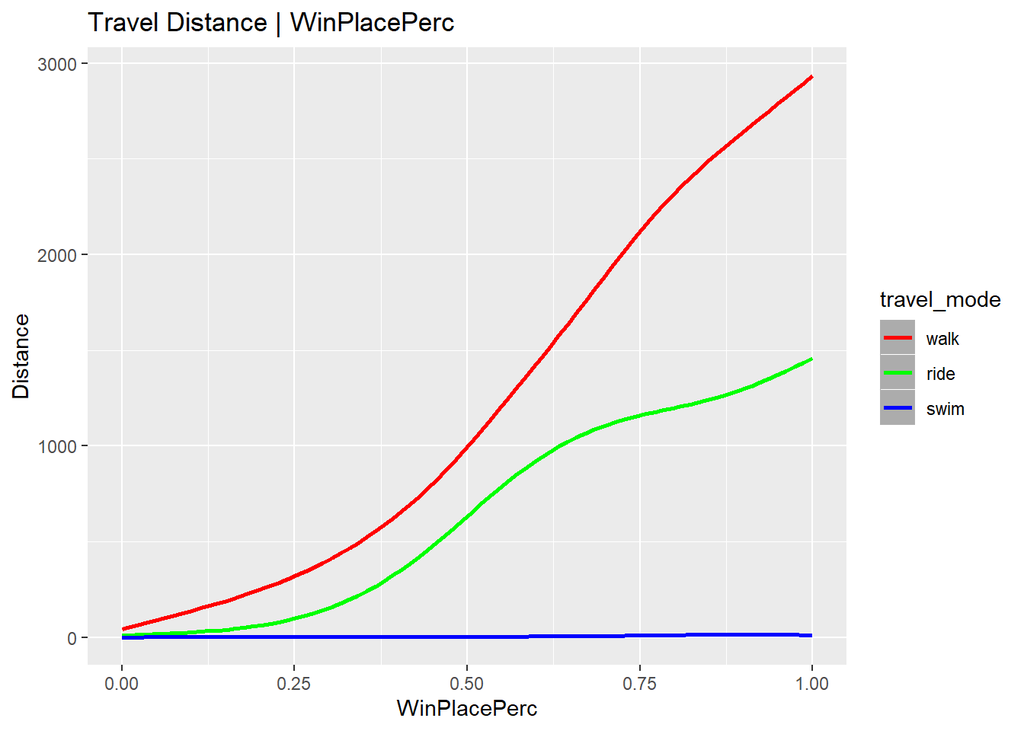

```r
ggplot(data = pubg1, aes(x=winPlacePerc)) +
  geom_smooth(aes(y = walkDistance,color = 'red')) +
  geom_smooth(aes(y = rideDistance,color = 'green'))+
  geom_smooth(aes(y = swimDistance, color = 'blue'))+
  labs(x = "WinPlacePerc",
         y = "Distance",
       title = 'Travel Distance | WinPlacePerc')+
  scale_color_identity(name = "travel_mode",
                          breaks = c("red","green","blue"),
                          labels = c("walk", "ride", "swim"),
                          guide = "legend")
```

## Conclusion

1. The average distance travelled consistently increases with the player’s placement decile. In short, the better player you are, the further your distance travelled.
2. Walking is always the first choice, which is much better than Riding and Swimming during the game.

# ● Finding 2: Sharpshoot skills

We know shooting skills are very important to the player, which will directly lead to win the final game. To measure players’ shooting skill, headshot accuracy is the best way to measure that headshot accuracy = headshotKills / kills.

## Analysis

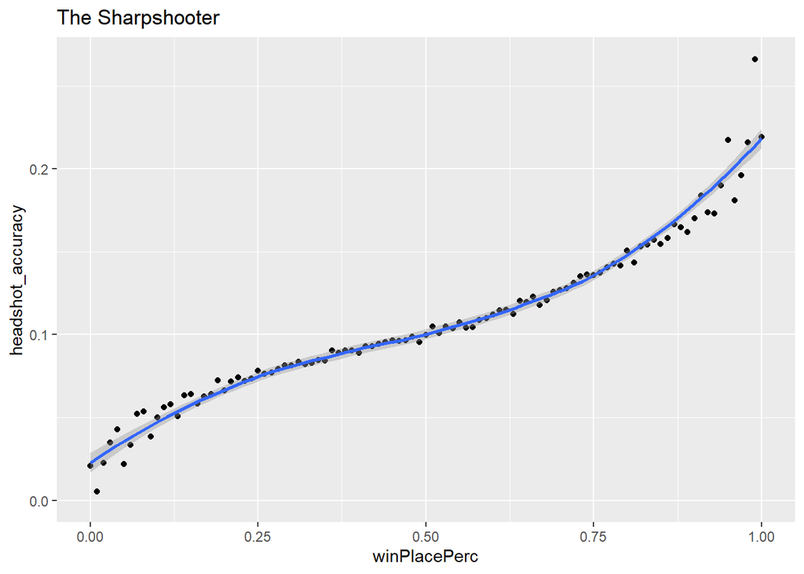

```r
sharpshoot <- pubg %>%
  select(Id, headshotKills, kills, winPlacePerc,matchType) %>%
  mutate(winPlacePerc = round(winPlacePerc, 2)) %>%
  group_by(winPlacePerc) %>%
  summarise(headshot_accuracy = mean(ifelse(kills == 0, 0, headshotKills / kills)))


ggplot(data = sharpshoot, aes(x = winPlacePerc, y = headshot_accuracy)) +
  geom_point() +
  geom_smooth(method = 'loess') +
  labs(title = 'The Sharpshooter')
```

From the plot, we can easily see higher accuracy leads to higher winPlacePerc. But here is the question, does match type will influence the result? From my experience, I am a bad shooter, when I attend solo match, I probably will choose to hide and run on most of time and finally I also can will the game. Then I will exam it through ploting the model by different match type.

[output not shown]

[output cut: 250 more lines]

[output not shown]

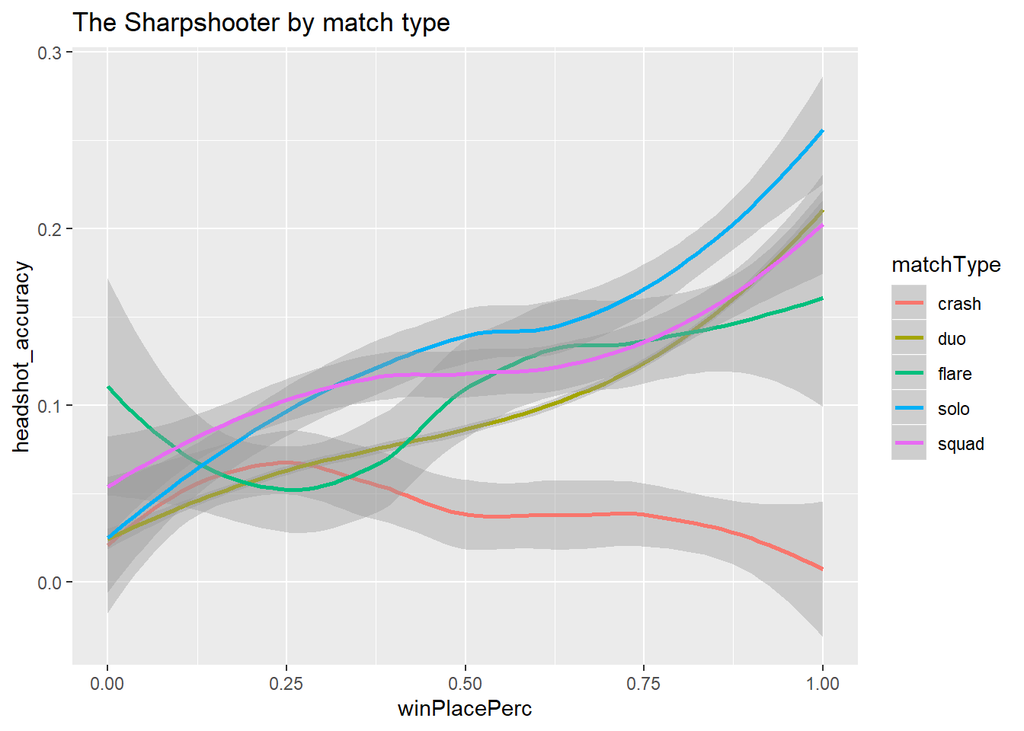

I am totally wrong! Except for the crash, other groups’ final winPercent are all related to the headshot accuracy. Maybe win by hiding is just by chance to me.

## Random slopes and intercept influence

```
## boundary (singular) fit: see ?isSingular
```

```
## Linear mixed model fit by REML ['lmerMod']
## Formula:
## winPlacePerc ~ headshot_accuracy + (1 + headshot_accuracy | matchType)
##    Data: sharpshootbymatchtype
##
## REML criterion at convergence: 159.4
##
## Scaled residuals:
##     Min      1Q  Median      3Q     Max
## -4.4039 -0.7538  0.0405  0.8083  2.3844
##
## Random effects:
##  Groups    Name              Variance Std.Dev. Corr
##  matchType (Intercept)       0.04918  0.2218
##            headshot_accuracy 5.91321  2.4317   -1.00
##  Residual                    0.06426  0.2535
## Number of obs: 1403, groups:  matchType, 5
##
## Fixed effects:
##                   Estimate Std. Error t value
## (Intercept)         0.2986     0.1002   2.980
## headshot_accuracy   1.7753     1.0954   1.621
##
## Correlation of Fixed Effects:
##             (Intr)
## hdsht_ccrcy -0.997
## convergence code: 0
## boundary (singular) fit: see ?isSingular
```

From std.Dev, we can see headshot accuracy cofficient change 2.4317 by different types of match, but intercept doesn’t change a lot.

From t value, intercept> 1.96 means it is significant. But for cofficient, it just very close.

So when we see the fixed effects, we see intercept’s t-value = 2.980, which is significant, then for cofficient = 1.621 which is not significant,which means matchtype do not fit the headshot_accuacy’s cofficient.

## Conclusion

1. Higher head_shot accuacy leads to higher final grade.
2. Shooting skills is very important in all kinds of games except for crash.

# ● Finding 3: Resources collection

Here is the question: When we farm in the jungle or city, how do I make the strategy of resource collection?

Do I need to collect weapons first, boost, or the heals?

## Analysis

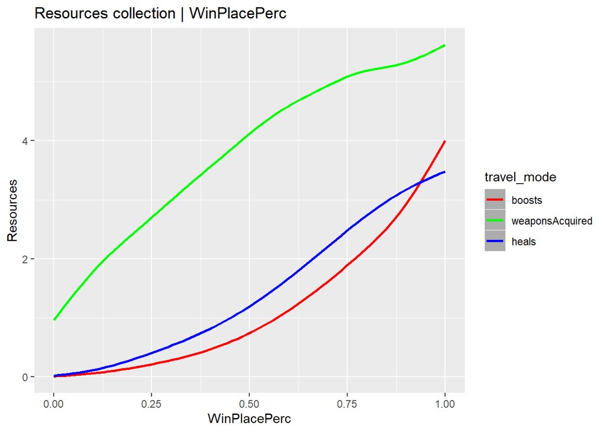

```r
ggplot(data = pubg1, aes(x = winPlacePerc)) +
  geom_smooth(aes(y = boosts,color = 'red')) +
  geom_smooth(aes(y = weaponsAcquired, color = 'green'))+
  geom_smooth(aes(y = heals, color = 'blue'))+
  labs(x = "WinPlacePerc",
         y = "Resources",
         colors = "Legend",
       title = 'Resources collection | WinPlacePerc') +
  scale_color_identity(name = "travel_mode",
                          breaks = c("red","green","blue"),
                          labels = c("boosts", "weaponsAcquired", "heals"),
                          guide = "legend")
```

Noramlly, weapons are the most important thing to win the final fight, the trend of boosts and heal are almost the same. But does the matchtype will influence our strategies?

## Interactions

Now, we put matchtype and different kinds of resources together into linear model to exam their interaction performances.

```r
resources <- pubg1%>%
  select(boosts,heals,weaponsAcquired,winPlacePerc,matchType)%>%
  mutate(matchType = as.character(matchType))%>%
  mutate(matchType = if_else((matchType=='crashfpp')|(matchType=='crashtpp'),'crash',matchType))%>%
  mutate(matchType = if_else((matchType=='flarefpp')|(matchType=='flaretpp'),'flare',matchType))%>%
  mutate(matchType = if_else((matchType=='normal-solo-fpp')|(matchType=='solo-fpp')|(matchType=='normal-solo'),'solo',matchType))%>%
  mutate(matchType = if_else((matchType=='duo-fpp')|(matchType=='normal-duo')|(matchType=='normal-duo-fpp'),'solo',matchType))%>%
  mutate(matchType = if_else((matchType=='squad-fpp')|(matchType=='normal-squad')|(matchType=='normal-squad-fpp'),'squad',matchType))%>%
  mutate(matchType = as.factor(matchType))%>%
  mutate(boosts = as.numeric(boosts))%>%
  mutate(heals = as.numeric(heals))
```

```r
weaponmod <- lm(winPlacePerc~ weaponsAcquired*matchType,data = resources)
summary(weaponmod)
```

```
##
## Call:
## lm(formula = winPlacePerc ~ weaponsAcquired * matchType, data = resources)
##
## Residuals:
##      Min       1Q   Median       3Q      Max
## -16.3681  -0.1941  -0.0333   0.1789   0.8919
##
## Coefficients:
##                                 Estimate Std. Error t value Pr(>|t|)
## (Intercept)                     0.348499   0.005057  68.920  < 2e-16 ***
## weaponsAcquired                 0.083026   0.002641  31.432  < 2e-16 ***
## matchTypeduo                   -0.157893   0.005122 -30.828  < 2e-16 ***
## matchTypeflare                 -0.240396   0.009748 -24.661  < 2e-16 ***
## matchTypesolo                  -0.130898   0.005068 -25.830  < 2e-16 ***
## matchTypesquad                 -0.151711   0.005065 -29.953  < 2e-16 ***
## weaponsAcquired:matchTypeduo   -0.004467   0.002648  -1.687  0.09158 .
## weaponsAcquired:matchTypeflare -0.007532   0.003099  -2.431  0.01507 *
## weaponsAcquired:matchTypesolo  -0.008050   0.002643  -3.046  0.00232 **
## weaponsAcquired:matchTypesquad -0.011628   0.002642  -4.401 1.08e-05 ***
## ---
## Signif. codes:  0 '***' 0.001 '**' 0.01 '*' 0.05 '.' 0.1 ' ' 1
##
## Residual standard error: 0.2489 on 4446955 degrees of freedom
## Multiple R-squared:  0.3444, Adjusted R-squared:  0.3444
## F-statistic: 2.595e+05 on 9 and 4446955 DF,  p-value: < 2.2e-16
```

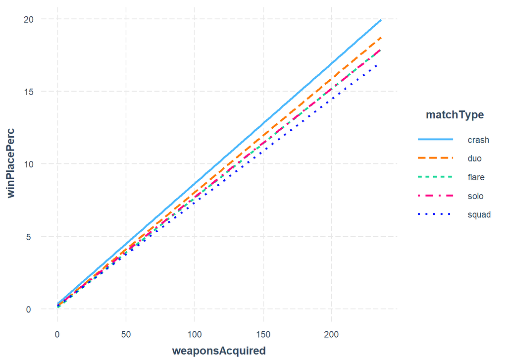

```r
weaponmodplot <- interact_plot(weaponmod,pred = weaponsAcquired,modx = matchType)
weaponmodplot
```

From weaponmod summary, we can see p value of weaponsAcquired: matchTypesquad, weaponsAcquired:matchTypesolo,weaponsAcquired:matchTypeflare is significant, so we should divide the weaponsAcquired inforamtion by different match type.

```r
boostsmod <- lm(winPlacePerc~ boosts*matchType,data = resources)
summary(boostsmod)
```

```
##
## Call:
## lm(formula = winPlacePerc ~ boosts * matchType, data = resources)
##
## Residuals:
##     Min      1Q  Median      3Q     Max
## -3.2384 -0.1907 -0.0182  0.1697  0.7125
##
## Coefficients:
##                        Estimate Std. Error t value Pr(>|t|)
## (Intercept)            0.351792   0.003625  97.056  < 2e-16 ***
## boosts                 0.109284   0.001917  57.002  < 2e-16 ***
## matchTypeduo           0.005498   0.003659   1.502 0.132998
## matchTypeflare        -0.064277   0.006287 -10.224  < 2e-16 ***
## matchTypesolo          0.015959   0.003631   4.396 1.11e-05 ***
## matchTypesquad        -0.021461   0.003629  -5.913 3.35e-09 ***
## boosts:matchTypeduo    0.001425   0.001932   0.738 0.460683
## boosts:matchTypeflare  0.002139   0.002925   0.731 0.464695
## boosts:matchTypesolo   0.001517   0.001920   0.790 0.429343
## boosts:matchTypesquad  0.007187   0.001919   3.745 0.000181 ***
## ---
## Signif. codes:  0 '***' 0.001 '**' 0.01 '*' 0.05 '.' 0.1 ' ' 1
##
## Residual standard error: 0.2371 on 4446955 degrees of freedom
## Multiple R-squared:  0.4049, Adjusted R-squared:  0.4049
## F-statistic: 3.362e+05 on 9 and 4446955 DF,  p-value: < 2.2e-16
```

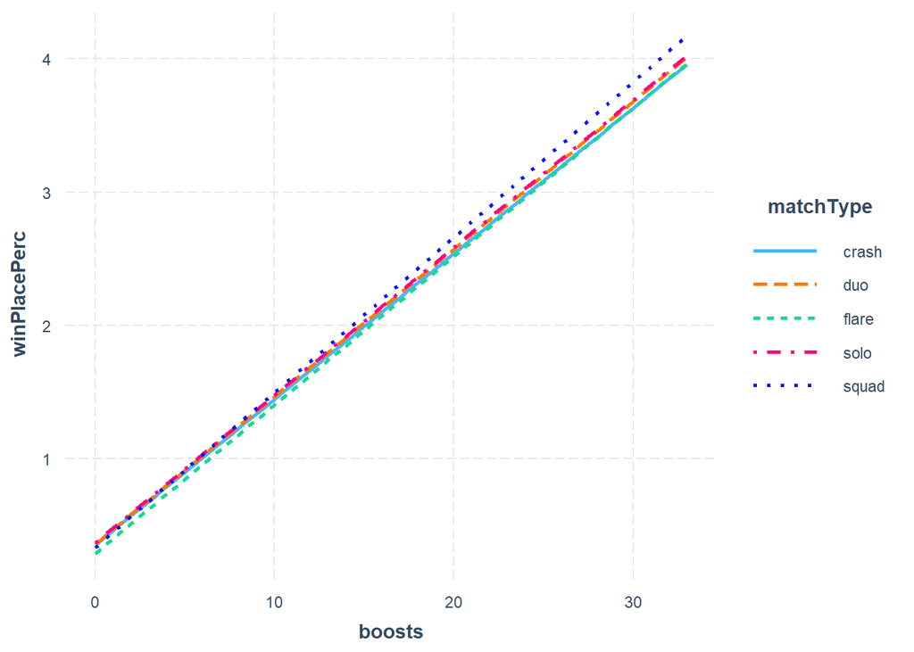

```r
boostsmodplot <- interact_plot(boostsmod,pred = boosts,modx = matchType)
boostsmodplot
```

```r
healsmod <- lm(winPlacePerc~ heals*matchType,data = resources)
summary(healsmod)
```

```
##
## Call:
## lm(formula = winPlacePerc ~ heals * matchType, data = resources)
##
## Residuals:
##     Min      1Q  Median      3Q     Max
## -3.5029 -0.2361 -0.0189  0.2215  0.6497
##
## Coefficients:
##                        Estimate Std. Error t value Pr(>|t|)
## (Intercept)           0.4167461  0.0038108 109.359  < 2e-16 ***
## heals                 0.0490701  0.0014486  33.874  < 2e-16 ***
## matchTypeduo         -0.0022052  0.0038510  -0.573   0.5669
## matchTypeflare       -0.0664519  0.0068182  -9.746  < 2e-16 ***
## matchTypesolo         0.0087124  0.0038180   2.282   0.0225 *
## matchTypesquad       -0.0274867  0.0038162  -7.203 5.91e-13 ***
## heals:matchTypeduo    0.0018907  0.0014607   1.294   0.1955
## heals:matchTypeflare -0.0012041  0.0021215  -0.568   0.5703
## heals:matchTypesolo   0.0018367  0.0014510   1.266   0.2056
## heals:matchTypesquad -0.0006495  0.0014500  -0.448   0.6542
## ---
## Signif. codes:  0 '***' 0.001 '**' 0.01 '*' 0.05 '.' 0.1 ' ' 1
##
## Residual standard error: 0.2772 on 4446955 degrees of freedom
## Multiple R-squared:  0.187,  Adjusted R-squared:  0.187
## F-statistic: 1.137e+05 on 9 and 4446955 DF,  p-value: < 2.2e-16
```

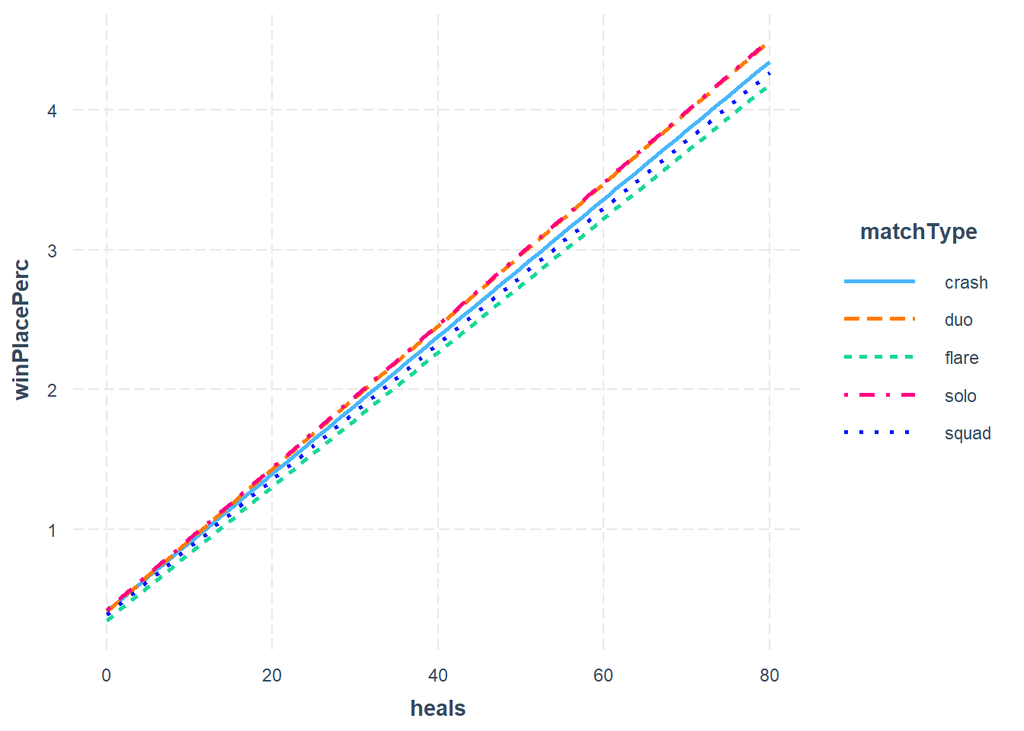

```r
healsmodplot <- interact_plot(healsmod,pred = heals,modx = matchType)
healsmodplot
```

From healsmod summary, we can see no p value in any combination of heals and match type.

## Conclusion:

# ● Finding Summary

1. The better player you are, the further your distance travelled. Travel priority: Walk > Ride >Swim.
2. Better shooting skills leads to final.
3. Weapon resources are the most important thing to collect.

# Winner Winner, Chicken Dinner